# 0212

#### Adding a covariate: do boys play more?

We can us a Poisson regression to estimate the difference in weekly rates of video game playing by boys and girls (keeping in mind the problematic way that Add Health collects data on gender).

$$ H_i \sim Pois(\lambda)\\ \log(\lambda) = \alpha + \beta M_i\\ \alpha \sim Norm(4,1)\\ \beta \sim Norm(0,0.5)\\ $$

It is usally a good idea for your non-intercept coefficients to have a mean of zero. This is because $\exp(0)=1$, so a value of zero for $\beta$ would mean being male has no association.

For the standard deviation, you almost always want a pretty narrow distribution when using a Poisson regression. We'll use 0.5 here, but you can experiment with others. Prior predictive plots can be useful here.

```r
# build the model
m2 <- alist(
    hours_games ~ dpois(lambda),
    log(lambda) <- alpha + beta*male,
    alpha ~ dnorm(4,1),
    beta ~ dnorm(0,0.5)
)
```

```r
# find complete cases
cc <- complete.cases(d[c('hours_games','male')])

# fit
fit2 <- map2stan(m2,data=d[cc,],iter=10000)
```

```
[ 5000 / 5000 ]
```

```r
precis(fit2)
```

```
      Mean StdDev lower 0.89 upper 0.89 n_eff Rhat
alpha 0.38   0.01       0.36       0.40  1334    1
beta  1.10   0.02       1.07       1.12  1346    1
```

```r
exp(coef(fit2))
```

**alpha**

1.46345611569809

**beta**

2.99018341913311

This tells a very different story. Girls in the sample play an average of about 1.46 hours per week, while boys play about 2.99 times more than girls:

$$\exp(\alpha + \beta) = \exp(\alpha)\times\exp(\beta)\\ \exp(0.38 + 1.10) = \exp(0.38)\times\exp(1.10) \\ 1.46\times2.99=4.37$$

Let's compare the posterior distriibutions of $\lambda$ for boys and girls.

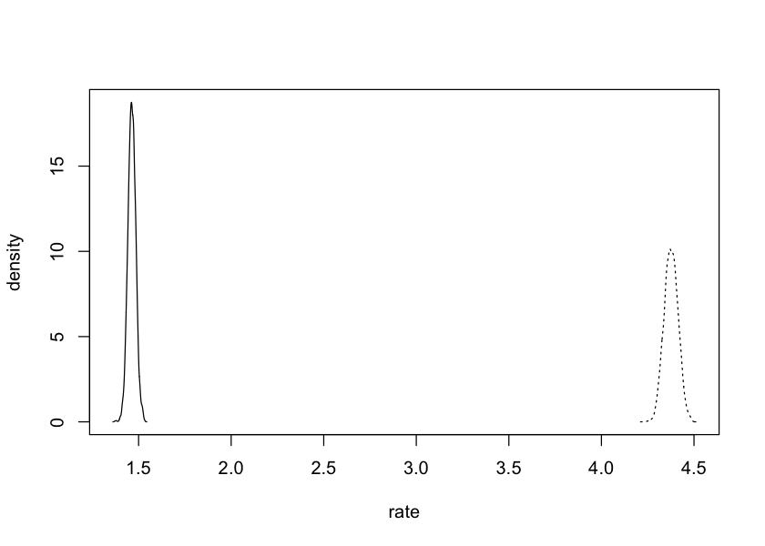

```r
samp2 <- extract.samples(fit2,5000)

pdens_girls <- density(exp(samp2$alpha))
pdens_boys <- density(exp(samp2$alpha + samp2$beta))

xlim <- range(pdens_girls$x,pdens_boys$x)
ylim <- range(pdens_girls$y,pdens_boys$y)

plot(NA,xlim=xlim,ylim=ylim,xlab='rate',ylab='density')
lines(pdens_girls,lty=1)
lines(pdens_boys,lty=3)
```

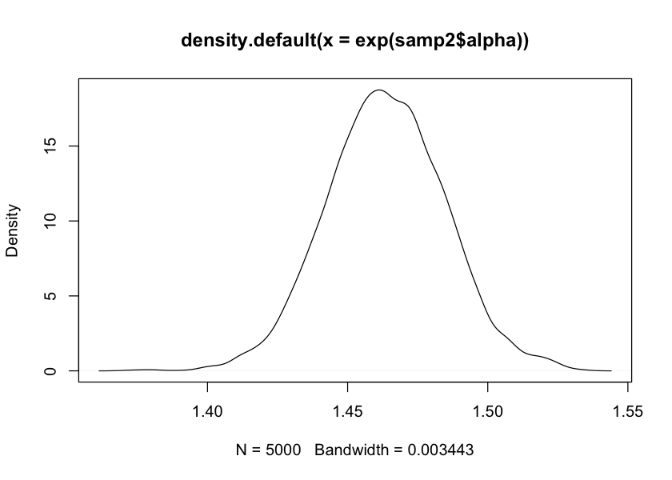

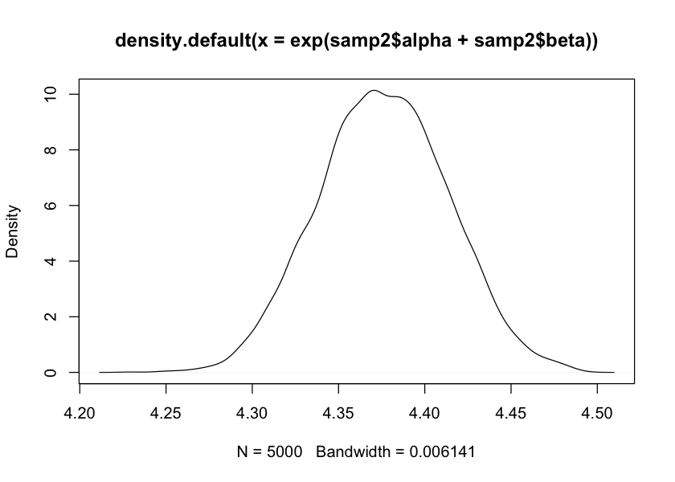

```r
# plot them separately to see more detail
plot(pdens_girls)
plot(pdens_boys)
```

#### Adding grade

We will use students' grade level, centered at 10th grade, as a further predictor.

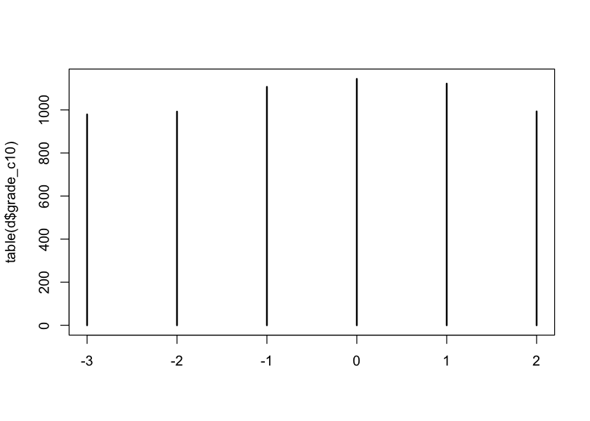

```r
d$grade_c10 <- d$grade-10
plot(table(d$grade_c10))
```

```r
# build the model
m3 <- alist(
    hours_games ~ dpois(lambda),
    log(lambda) <- alpha + beta_m*male + beta_g*grade_c10,
    alpha ~ dnorm(4,1),
    beta_m ~ dnorm(0,0.5),
    beta_g ~ dnorm(0,0.3) # grade has a bigger range
)
# find complete cases
cc <- complete.cases(d[c('hours_games','male','grade_c10')])

# fit
fit3 <- map2stan(m3,data=d[cc,],iter=10000)
```

```
[ 5000 / 5000 ]
```

```r
precis(fit3,prob=.9)
exp(coef(fit3))
```

```
        Mean StdDev lower 0.9 upper 0.9 n_eff Rhat
alpha   0.28   0.02      0.25      0.30  1820    1
beta_m  1.11   0.02      1.08      1.14  1735    1
beta_g -0.14   0.00     -0.15     -0.13  3252    1
```

**alpha**

1.31674842568102

**beta_m**

3.04691060880975

**beta_g**

0.868638524373606

The values for $\alpha$ and $\beta_M$ did not change much, but the estimate for $\beta_G$ (the coefficient on grade level) is negative. Older students tend to report playing games for less time than younger students.

Specifically, our model predicts that for each grade level a student achieves, their rate of playing video games will be multiplied by about 0.869. This corresponds to an annual decrease of about 13.1%.